# biodiversity_access

```python
import pandas as pd
import numpy as np
import matplotlib.pyplot as plt
import seaborn as sns
import plotly.express as px
import math
import plotly.graph_objects as go
from sklearn.cluster import KMeans
from sklearn.preprocessing import StandardScaler
import re
```

```python
df = pd.read_csv('/Users/avr/Downloads/WB_GBIOD.csv')
```

```python
df_dict = pd.read_csv('/Users/avr/Downloads/WB_GBIOD_DATADICT.csv')
```

```python
keep_cols = [
    "REF_AREA", "REF_AREA_LABEL",
    "TIME_PERIOD",
    "INDICATOR", "INDICATOR_LABEL",
    "OBS_VALUE"
]

df_core = df[keep_cols].copy()


df_core = df_core.rename(columns={
    "REF_AREA": "geo_iso3",
    "REF_AREA_LABEL": "geo_name",
    "TIME_PERIOD": "year",
    "INDICATOR": "indicator_id",
    "INDICATOR_LABEL": "indicator_name",
    "OBS_VALUE": "value"
})


df_core["year"] = pd.to_numeric(df_core["year"], errors="coerce").astype("Int64")
df_core["value"] = pd.to_numeric(df_core["value"], errors="coerce")


print("df_core shape:", df_core.shape)
print("years:", df_core["year"].dropna().unique()[:10], "nunique:", df_core["year"].nunique())
print("indicators:", df_core["indicator_id"].nunique())
print("geo units:", df_core["geo_iso3"].nunique())
print("value non-null:", df_core["value"].notna().sum())


dupes = df_core.duplicated(subset=["geo_iso3","indicator_id","year"]).sum()
print("duplicate geo+indicator+year rows:", dupes)


indicator_short = {
    "WB_GBIOD_N_SPP_SMALL50XENDEMIC100": "endemic_small_range",
    "WB_GBIOD_N_SPP_TOTAL": "total_species",
    "WB_GBIOD_N_SPP_TPROB80": "threat_prob80_species"
}
df_core["indicator_short"] = df_core["indicator_id"].map(indicator_short).fillna(df_core["indicator_id"])

df_core.head()
```

```
df_core shape: (705, 6)
years: <IntegerArray>
[2024]
Length: 1, dtype: Int64 nunique: 1
indicators: 3
geo units: 235
value non-null: 705
duplicate geo+indicator+year rows: 0
```

|  | geo_iso3 | geo_name | year | indicator_id | indicator_name | value | indicator_short |
| --- | --- | --- | --- | --- | --- | --- | --- |
| 0 | ALB | Albania | 2024 | WB_GBIOD_N_SPP_SMALL50XENDEMIC100 | Number of endemic species with small occurrenc... | 31.0 | endemic_small_range |
| 1 | DZA | Algeria | 2024 | WB_GBIOD_N_SPP_SMALL50XENDEMIC100 | Number of endemic species with small occurrenc... | 47.0 | endemic_small_range |
| 2 | ASM | American Samoa | 2024 | WB_GBIOD_N_SPP_SMALL50XENDEMIC100 | Number of endemic species with small occurrenc... | 15.0 | endemic_small_range |
| 3 | AGO | Angola | 2024 | WB_GBIOD_N_SPP_SMALL50XENDEMIC100 | Number of endemic species with small occurrenc... | 89.0 | endemic_small_range |
| 4 | AIA | Anguilla | 2024 | WB_GBIOD_N_SPP_SMALL50XENDEMIC100 | Number of endemic species with small occurrenc... | 2.0 | endemic_small_range |

```python
wide = (df_core.pivot_table(
            index=["geo_iso3","geo_name","year"],
            columns="indicator_short",
            values="value",
            aggfunc="first"
        ).reset_index())

wide.head()
```

| indicator_short | geo_iso3 | geo_name | year | endemic_small_range | threat_prob80_species | total_species |
| --- | --- | --- | --- | --- | --- | --- |
| 0 | ABW | Aruba | 2024 | 7.0 | 202.0 | 8656.0 |
| 1 | AFG | Afghanistan | 2024 | 17.0 | 49.0 | 4667.0 |
| 2 | AGO | Angola | 2024 | 89.0 | 73.0 | 7872.0 |
| 3 | AIA | Anguilla | 2024 | 2.0 | 140.0 | 6097.0 |
| 4 | ALB | Albania | 2024 | 31.0 | 165.0 | 16505.0 |

**total_species** size of the country's "bio-base" (not the risk per se).

**endemic_small_range** (endemics with a small range) - vulnerability: the more such species, the greater the risk that local changes will kill off unique species.

**threat_prob80_species** (species with a threat/extinction probability ≥ 80% — as the name suggests) - a clear red flag: the larger, the worse.

!!!Important: these are counts, so larger countries will often be "worse" simply due to their scale.

Absolute value is simply “how many pieces”. So Absolutes almost always grow with the size of the system!

```python
# ration metrics

wide = wide.copy()

wide["threat_share"] = wide["threat_prob80_species"] / wide["total_species"]
wide["endemic_share"] = wide["endemic_small_range"] / wide["total_species"]
wide["endemic_vs_threat"] = wide["endemic_small_range"] / wide["threat_prob80_species"]
```

`endemic_vs_threat` is best read as follows:

- `< 1` → more threatened species than endemics (narrow-range species)
- `≈ 1` → roughly the same
- `> 1` → more endemics than threatened But this isn't good/bad in itself—it's a type of risk.

```python
# comfy percents

wide["threat_pct"] = 100 * wide["threat_share"]
wide["endemic_pct"] = 100 * wide["endemic_share"]
```

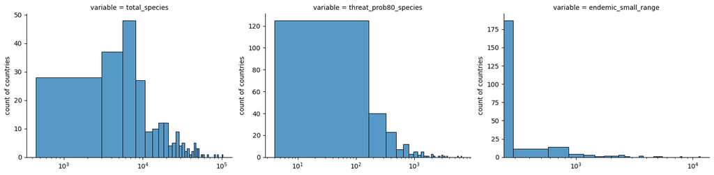

```python
# “Shape of the world”: distributions (counts vs. shares)

cols_abs = ["total_species", "threat_prob80_species", "endemic_small_range"]


long_df = wide[cols_abs].astype(float).melt(
    value_vars=cols_abs,
    var_name="variable",
    value_name="value"
)


g = sns.FacetGrid(
    long_df,
    col="variable",
    sharex=False,
    sharey=False,
    height=4,
    aspect=1.3
)

g.map_dataframe(
    sns.histplot,
    x="value",
    bins=40
)


for ax in g.axes.flat:
    ax.set_xscale("log")
    ax.set_xlabel("")
    ax.set_ylabel("count of countries")

plt.show()
```

### Distributions of absolute counts (log scale): total_species, threat_prob80_species, endemic_small_range

All three variables are highly right-skewed: most countries have relatively small values, and a few countries have extremely large values.

Using a log scale is necessary here — otherwise the “big” countries would compress everything else near zero.

**Why it matters**

Absolute numbers are strongly driven by country scale / biodiversity richness (more total species -> usually more threatened species).

This is a first hint that we should not rely only on absolutes for comparisons across countries.

**Interpretation**

`total_species` is a “size” proxy (how biodiverse a country is in total).

`threat_prob80_species` partly reflects risk, but also mostly reflects size.

`endemic_small_range` is also size-related, but can signal unique vulnerability (species with narrow ranges are more fragile).

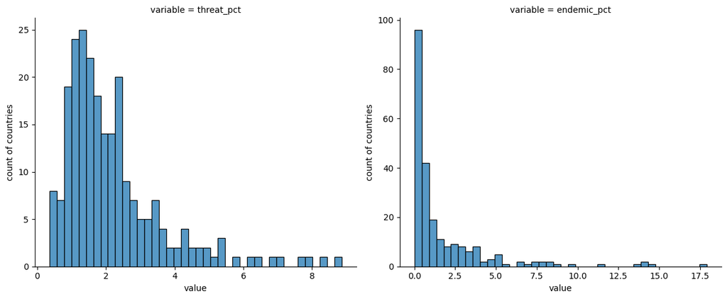

```python
# Shares/percentages

cols_pct = ["threat_pct", "endemic_pct"]


long_pct = wide[cols_pct].astype(float).melt(
    value_vars=cols_pct,
    var_name="variable",
    value_name="value"
)

g = sns.FacetGrid(
    long_pct,
    col="variable",
    sharex=False,
    sharey=False,
    height=5,
    aspect=1.2
)

g.map_dataframe(
    sns.histplot,
    x="value",
    bins=40
)

for ax in g.axes.flat:
    ax.set_ylabel("count of countries")

plt.show()
```

### Histograms of shares: threat_pct vs endemic_pct

**What we see**

`threat_pct` is right-skewed, but still has a meaningful spread across many countries.

`endemic_pct` is extremely concentrated near zero (many countries have tiny endemic share), with a long tail of countries that are true outliers.

**Why it matters**

`endemic_pct` behaves like a “rare but important” feature: mostly low, but when it’s high it’s a big deal.

This supports a “segmentation mindset”:

most countries are not endemic-heavy,

but a minority are high endemism hotspots

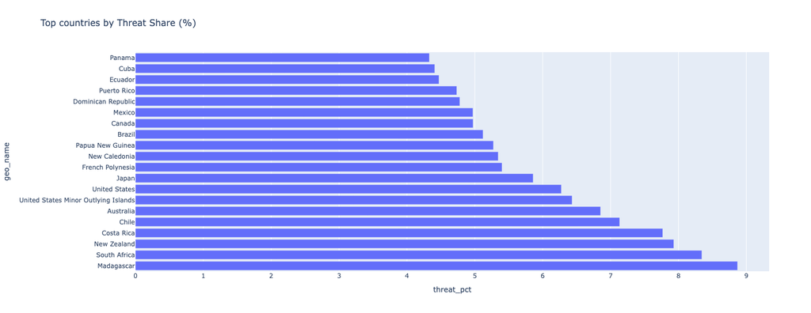

```python
# Who is extreme? top and annti-top

def top_bar(metric, n=15, title=None):
    d = wide.sort_values(metric, ascending=False).head(n)
    fig = px.bar(d, x=metric, y="geo_name", orientation="h",
                 title=title or f"Top {n} countries by {metric}",
                 hover_data=["geo_iso3", "total_species", "threat_prob80_species", "endemic_small_range",
                             "threat_pct", "endemic_pct"])
    fig.update_layout(height=600)
    fig.show()

top_bar("threat_pct", 20, "Top countries by Threat Share (%)")
```

### Top countries by `threat_pct` (Threat share %)

**What we see**

This ranking highlights countries where a large fraction of species are threatened.

Some overlap with the endemic ranking, but not identical — meaning threat pressure != endemism.

**Why it matters**

High `threat_pct` is closer to a “current pressure” signal.

It’s a strong candidate for “where intervention / monitoring is urgent”.

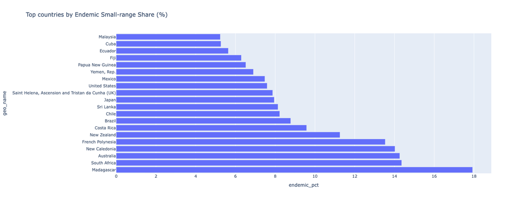

```python
top_bar("endemic_pct", 20, "Top countries by Endemic Small-range Share (%)")
```

### Top countries by endemic_pct (Endemic small-range share %)

**What we see**

The top of the ranking is dominated by a mix of:

islands / territories (often high endemism),

and some large biodiversity-rich countries.

The distribution suggests endemic vulnerability is concentrated in a relatively small set of places.

**Why it matters**

High `endemic_pct` indicates ecosystems with many small-range endemic species, which are typically more sensitive to habitat loss and disruption.

This is a good candidate signal for “where biodiversity loss could be irreversible”.

**Caveat**

Shares can be high partly because the denominator (total_species) behaves differently across places.

It’s useful to show both:

share ranking (relative vulnerability),

and absolute endemic counts (magnitude)

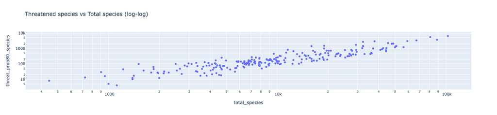

```python
# Absolute vs. Size: Which of the absolutes is simply scale?

fig = px.scatter(
    wide, x="total_species", y="threat_prob80_species",
    hover_name="geo_name",
    hover_data=["threat_pct","endemic_pct"],
    log_x=True, log_y=True,
    title="Threatened species vs Total species (log-log)"
)
fig.show()
```

### Log–log scatter: `threat_prob80_species` vs `total_species`

**What we see**

A strong upward trend: countries with more total species usually have more threatened species.

The relationship looks close to scaling (almost “proportional” on log–log).

**Why it matters**

This is a classic “scale effect”: absolute threatened counts are not comparable without controlling for total species.

That’s exactly why our normalized features (`threat_share`, `endemic_share`) are needed — they reduce the “big country advantage”.

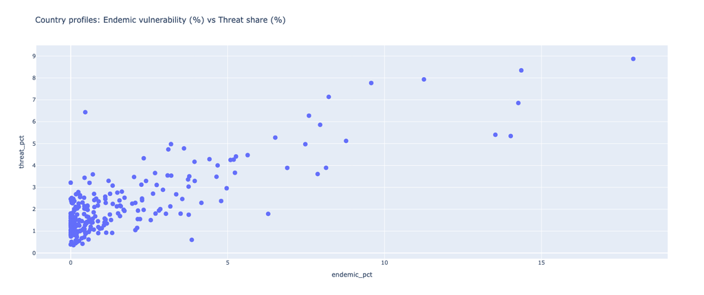

```python
# threat_share vs endemic_share types of countries

fig = px.scatter(
    wide, x="endemic_pct", y="threat_pct",
    hover_name="geo_name",
    hover_data=["total_species", "threat_prob80_species", "endemic_small_range"],
    title="Country profiles: Endemic vulnerability (%) vs Threat share (%)"
)

fig.update_traces(
    marker=dict(size=10))

fig.update_layout(height=650)
fig.show()
```

### Scatter: `endemic_pct` vs `threat_pct` (Country profiles)

**What we see**

Most countries cluster near low endemic share and low-to-medium threat share.

There’s a positive relationship: countries with higher endemic share often also have higher threat share — but it’s not perfect (there’s visible spread).

**Why it matters**

This plot shows two different risk dimensions:

- Endemic vulnerability (how much of biodiversity is “locally fragile/unique”)
- Threat pressure (how much biodiversity is threatened overall)

A country can score high on one and not the other -> different risk profiles.

**How to read it**

Top-right: “double risk” (high endemic vulnerability + high threat pressure).

High endemic, low threat: unique ecosystems but not (yet) heavily threatened.

Low endemic, high threat: many species threatened, but not necessarily endemic-heavy.

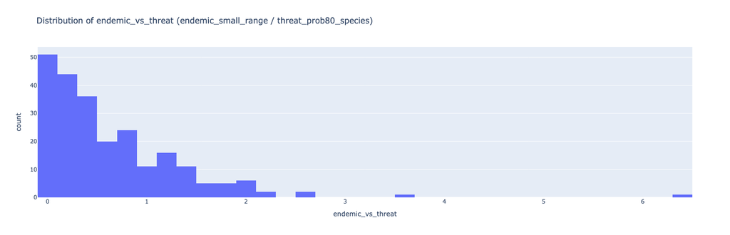

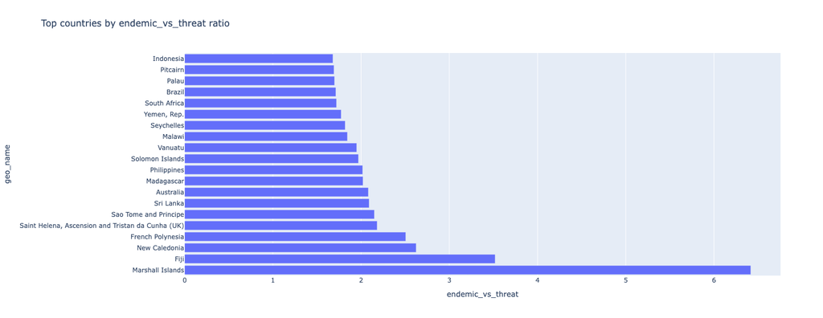

```python
# endemic_vs_threat

fig = px.histogram(
    wide, x="endemic_vs_threat", nbins=60,
    title="Distribution of endemic_vs_threat (endemic_small_range / threat_prob80_species)"
)
fig.update_layout(height=500)
fig.show()

top_bar("endemic_vs_threat", 20, "Top countries by endemic_vs_threat ratio")

fig.write_html("endemic_vs_threat.html")
```

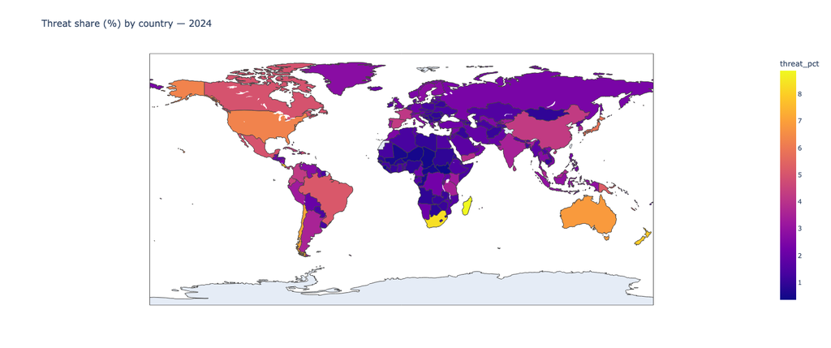

```python
# Threat share map and Endemic share map

fig = px.choropleth(
    wide, locations="geo_iso3", color="threat_pct",
    hover_name="geo_name",
    title="Threat share (%) by country — 2024"
)
fig.update_layout(width=1200, height=650)
fig.show()
fig.write_html("threat_share_country.html")
```

## Endemic small-range share (%) by country — 2024 (map)

**How to read**

- Colors show **endemic_pct**: the % of total species that are *endemic with small occurrence range*.
- Brighter/warmer colors = higher endemic vulnerability.

**What we see**

- The map is **highly uneven**: most countries are low, but a few stand out strongly.
- High endemic share often appears in places that are **geographically isolated** (islands) or have unique ecosystems.
- A key interpretation: high endemic_pct means a larger fraction of biodiversity is “place-specific” and can be harder to replace if habitats degrade.

**Why it matters**

- **Endemic_pct works like a vulnerability signal**:
  - If a country has many narrow-range endemic species, habitat loss can cause disproportionate biodiversity damage.
- This supports a story like: “biodiversity risk is concentrated, not uniform.”

**Caveats**

- Endemic_pct is a **relative metric**:
  - A country can have low endemic_pct but still have a large absolute number of endemic species.
- Country borders are not ecological borders; risk is not evenly distributed across the territory.

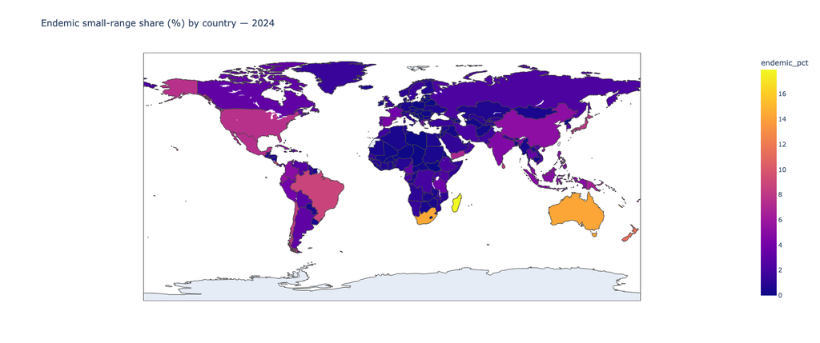

```python
fig = px.choropleth(
    wide, locations="geo_iso3", color="endemic_pct",
    hover_name="geo_name",
    title="Endemic small-range share (%) by country — 2024"
)
fig.update_layout(width=1200, height=650)
fig.show()
fig.write_html("endemic_share_country.html")
```

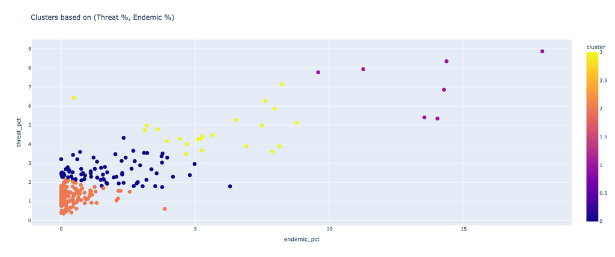

```python
# Mini-clustering to see segments without manual analysis

X = wide[["threat_pct", "endemic_pct"]].astype(float).copy()
X = X.fillna(0)

Xs = StandardScaler().fit_transform(X)

k = 4
km = KMeans(n_clusters=k, random_state=42, n_init="auto")
wide["cluster"] = km.fit_predict(Xs)

fig = px.scatter(
    wide, x="endemic_pct", y="threat_pct",
    color="cluster", hover_name="geo_name",
    title="Clusters based on (Threat %, Endemic %)"
)

fig.update_traces(
    marker=dict(size=10))

fig.update_layout(height=650)
fig.show()
fig.write_html("clusters_kNN.html")
```

## Clusters based on (Threat %, Endemic %)

**How to read**

- Each dot is a country.
- **x-axis (endemic_pct)** = share of *endemic small-range species* in total species (in %).
- **y-axis (threat_pct)** = share of *high-extinction-risk species (prob > 0.8)* in total species (in %).
- Colors show **clusters** (k-means). Note: cluster numbers are arbitrary labels.

**What we see**

- The data naturally forms a few “country profiles”:
  - **Low endemic + low threat**: many countries sit near the bottom-left (low % on both axes).
  - **Low endemic + moderate threat**: some countries have low endemic share but non-trivial threat share (higher y, still low x).
  - **Medium endemic + high threat**: a smaller group has both metrics elevated (middle-right + higher y).
  - **Very high endemic + high threat (outliers)**: a tiny set stands far to the right and high up — these are the most “fragile” profiles.
- The scatter suggests a **positive association**: countries with higher endemic vulnerability often also show higher threat share (not perfectly, but the pattern is visible).

**Why it matters**

- This is a simple way to **segment countries** into biodiversity-risk “buckets”.
- For a product angle (later): these clusters could become **risk tiers** (e.g., baseline country risk bands) that can be combined with business exposure data.

**Caveats**

- This is a **single-year snapshot (2024)** → no trend or causality.
- Country-level aggregation hides within-country hotspots (risk can be very local).
- Cluster results depend on chosen features (only 2 here) and the chosen k.

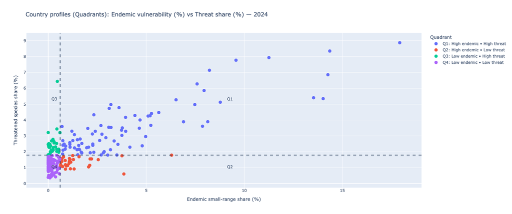

```python
# Quadrants overlay

import numpy as np
import pandas as pd
import plotly.express as px
import plotly.graph_objects as go

# --- choose thresholds (median is robust for skew) ---
x_col = "endemic_pct"
y_col = "threat_pct"

x_thr = wide[x_col].median()
y_thr = wide[y_col].median()

# --- assign quadrant labels ---
def assign_quadrant(x, y, x_thr, y_thr):
    if (x >= x_thr) and (y >= y_thr):
        return "Q1: High endemic • High threat"
    if (x >= x_thr) and (y < y_thr):
        return "Q2: High endemic • Low threat"
    if (x < x_thr) and (y >= y_thr):
        return "Q3: Low endemic • High threat"
    return "Q4: Low endemic • Low threat"

wide_q = wide.copy()
wide_q["quadrant"] = [
    assign_quadrant(x, y, x_thr, y_thr) for x, y in zip(wide_q[x_col], wide_q[y_col])
]

# (optional) nicer ordering in legend
quad_order = [
    "Q1: High endemic • High threat",
    "Q2: High endemic • Low threat",
    "Q3: Low endemic • High threat",
    "Q4: Low endemic • Low threat",
]

# --- interactive scatter ---
hover_cols = ["geo_name", "geo_iso3", x_col, y_col]
for extra in ["total_species", "threat_prob80_species", "endemic_small_range"]:
    if extra in wide_q.columns:
        hover_cols.append(extra)

fig = px.scatter(
    wide_q,
    x=x_col,
    y=y_col,
    color="quadrant",
    category_orders={"quadrant": quad_order},
    hover_name="geo_name",
    hover_data=hover_cols,
    title="Country profiles (Quadrants): Endemic vulnerability (%) vs Threat share (%) — 2024",
)

# --- add quadrant lines ---
fig.add_vline(x=x_thr, line_dash="dash")
fig.add_hline(y=y_thr, line_dash="dash")

# --- annotate quadrants ---
x_min, x_max = wide_q[x_col].min(), wide_q[x_col].max()
y_min, y_max = wide_q[y_col].min(), wide_q[y_col].max()

# place labels roughly in the middle of each quadrant
fig.add_annotation(x=(x_thr + x_max)/2, y=(y_thr + y_max)/2, text="Q1", showarrow=False)
fig.add_annotation(x=(x_thr + x_max)/2, y=(y_min + y_thr)/2, text="Q2", showarrow=False)
fig.add_annotation(x=(x_min + x_thr)/2, y=(y_thr + y_max)/2, text="Q3", showarrow=False)
fig.add_annotation(x=(x_min + x_thr)/2, y=(y_min + y_thr)/2, text="Q4", showarrow=False)

fig.update_layout(
    xaxis_title="Endemic small-range share (%)",
    yaxis_title="Threatened species share (%)",
    legend_title_text="Quadrant",
    width=1200, height=650
)
fig.update_traces(
    marker=dict(size=10))

fig.show()

# --- quick summary table: how many countries in each quadrant ---
quad_counts = (wide_q["quadrant"]
               .value_counts()
               .reindex(quad_order)
               .rename_axis("quadrant")
               .reset_index(name="n_countries"))
quad_counts
fig.write_html("quadrants_country.html")
```

### Quadrant view: country biodiversity profiles (2024 snapshot)

To make the scatter plot easier to interpret, we split countries into four quadrants using the median values of:

- **Endemic share (%)** = endemic small-range species / total species
- **Threat share (%)** = threatened species / total species

This creates four intuitive country profiles:

- **Q1 (High endemic, High threat):** potentially the most fragile biodiversity hotspots — high uniqueness and high pressure at the same time.
- **Q2 (High endemic, Low threat):** high vulnerability due to unique species, but lower current threat share (may reflect better protection or different pressures).
- **Q3 (Low endemic, High threat):** biodiversity pressure is high, even though the share of endemic species is lower (risk driven more by general threats).
- **Q4 (Low endemic, Low threat):** baseline profile in this dataset.

Important note: quadrant assignment depends on the chosen thresholds (here: medians), so this is a **relative segmentation**, not an absolute “good/bad” label. !! we can count by 75-th percentile if we want really hight hight later

```python
# Top 10 per each quadrant

wide_q["intensity"] = np.sqrt((wide_q[x_col] - x_thr)**2 + (wide_q[y_col] - y_thr)**2)

top_per_quad = (wide_q
                .sort_values(["quadrant", "intensity"], ascending=[True, False])
                .groupby("quadrant")
                .head(10)
                [["quadrant", "geo_name", "geo_iso3", x_col, y_col, "intensity"]])

top_per_quad
```

| indicator_short | quadrant | geo_name | geo_iso3 | endemic_pct | threat_pct | intensity |
| --- | --- | --- | --- | --- | --- | --- |
| 131 | Q1: High endemic • High threat | Madagascar | MDG | 17.926715 | 8.869402 | 18.710619 |
| 232 | Q1: High endemic • High threat | South Africa | ZAF | 14.358197 | 8.343904 | 15.232884 |
| 11 | Q1: High endemic • High threat | Australia | AUS | 14.263629 | 6.851687 | 14.564509 |
| 149 | Q1: High endemic • High threat | New Caledonia | NCL | 14.021312 | 5.344123 | 13.877503 |
| 174 | Q1: High endemic • High threat | French Polynesia | PYF | 13.532551 | 5.400213 | 13.420563 |
| 159 | Q1: High endemic • High threat | New Zealand | NZL | 11.255731 | 7.930653 | 12.291868 |
| 48 | Q1: High endemic • High threat | Costa Rica | CRI | 9.576578 | 7.767581 | 10.778164 |
| 38 | Q1: High endemic • High threat | Chile | CHL | 8.222376 | 7.132976 | 9.301941 |
| 29 | Q1: High endemic • High threat | Brazil | BRA | 8.774983 | 5.120711 | 8.820892 |
| 106 | Q1: High endemic • High threat | Japan | JPN | 7.948465 | 5.859095 | 8.393251 |
| 68 | Q2: High endemic • Low threat | Fiji | FJI | 6.292440 | 1.788139 | 5.686618 |
| 134 | Q2: High endemic • Low threat | Marshall Islands | MHL | 3.857715 | 0.601202 | 3.463442 |
| 193 | Q2: High endemic • Low threat | Sao Tome and Principe | STP | 3.760385 | 1.749016 | 3.154869 |
| 166 | Q2: High endemic • Low threat | Palau | PLW | 2.550915 | 1.501749 | 1.966792 |
| 146 | Q2: High endemic • Low threat | Malawi | MWI | 2.116520 | 1.147377 | 1.642914 |
| 185 | Q2: High endemic • Low threat | Solomon Islands | SLB | 2.059895 | 1.045793 | 1.634869 |
| 66 | Q2: High endemic • Low threat | Ethiopia | ETH | 2.208250 | 1.548842 | 1.620936 |
| 72 | Q2: High endemic • Low threat | Gabon | GAB | 2.135839 | 1.548484 | 1.549447 |
| 181 | Q2: High endemic • Low threat | Senegal | SEN | 1.321117 | 0.916258 | 1.131592 |
| 2 | Q2: High endemic • Low threat | Angola | AGO | 1.130589 | 0.927337 | 1.012388 |
| 218 | Q3: Low endemic • High threat | United States Minor Outlying Islands | UMI | 0.464191 | 6.432361 | 4.641419 |
| 57 | Q3: Low endemic • High threat | Dominica | DMA | 0.441117 | 3.435370 | 1.650505 |
| 183 | Q3: Low endemic • High threat | South Georgia and the South Sandwich Islands | SGS | 0.000000 | 3.211517 | 1.542375 |
| 91 | Q3: Low endemic • High threat | Haiti | HTI | 0.598629 | 3.205561 | 1.412476 |
| 225 | Q3: Low endemic • High threat | Virgin Islands (U.S.) | VIR | 0.242687 | 2.784519 | 1.055828 |
| 224 | Q3: Low endemic • High threat | British Virgin Islands | VGB | 0.169539 | 2.684374 | 0.992324 |
| 112 | Q3: Low endemic • High threat | St. Kitts and Nevis | KNA | 0.029595 | 2.515537 | 0.924094 |
| 199 | Q3: Low endemic • High threat | Sint Maarten (Dutch part) | SXM | 0.000000 | 2.467420 | 0.906490 |
| 17 | Q3: Low endemic • High threat | Bonaire (Neth.) | BES | 0.297501 | 2.637842 | 0.899248 |
| 127 | Q3: Low endemic • High threat | St. Martin (French part) | MAF | 0.084703 | 2.473319 | 0.856890 |
| 192 | Q4: Low endemic • Low threat | South Sudan | SSD | 0.000000 | 0.387680 | 1.530437 |
| 158 | Q4: Low endemic • Low threat | Nauru | NRU | 0.089366 | 0.357462 | 1.525711 |
| 203 | Q4: Low endemic • Low threat | Chad | TCD | 0.028523 | 0.484883 | 1.429936 |
| 79 | Q4: Low endemic • Low threat | Guinea-Bissau | GNB | 0.157315 | 0.445726 | 1.420065 |
| 150 | Q4: Low endemic • Low threat | Niger | NER | 0.024337 | 0.511073 | 1.407739 |
| 186 | Q4: Low endemic • Low threat | Sierra Leone | SLE | 0.375774 | 0.419982 | 1.392259 |
| 214 | Q4: Low endemic • Low threat | Tuvalu | TUV | 0.200200 | 0.500501 | 1.354752 |
| 136 | Q4: Low endemic • Low threat | Mali | MLI | 0.160624 | 0.573658 | 1.298172 |
| 34 | Q4: Low endemic • Low threat | Central African Republic | CAF | 0.266856 | 0.551503 | 1.287039 |
| 230 | Q4: Low endemic • Low threat | Kosovo | XKX | 0.007431 | 0.750483 | 1.202136 |

## Top by each metric

```python
# assume wide_q exists; if not, just use wide
df = wide_q.copy() if "wide_q" in globals() else wide.copy()

cols_needed = ["geo_name", "geo_iso3", "endemic_pct", "threat_pct",
               "endemic_small_range", "threat_prob80_species", "total_species"]
cols_present = [c for c in cols_needed if c in df.columns]
df = df[cols_present].copy()

TOP_N = 15

top_endemic_pct = df.sort_values("endemic_pct", ascending=False).head(TOP_N)
top_threat_pct  = df.sort_values("threat_pct",  ascending=False).head(TOP_N)

top_endemic_abs = df.sort_values("endemic_small_range", ascending=False).head(TOP_N)
top_threat_abs  = df.sort_values("threat_prob80_species", ascending=False).head(TOP_N)

top_total_species = df.sort_values("total_species", ascending=False).head(TOP_N)
```

```python
top_endemic_pct[["geo_name","geo_iso3","endemic_pct","endemic_small_range","total_species"]]
```

| indicator_short | geo_name | geo_iso3 | endemic_pct | endemic_small_range | total_species |
| --- | --- | --- | --- | --- | --- |
| 131 | Madagascar | MDG | 17.926715 | 2862.0 | 15965.0 |
| 232 | South Africa | ZAF | 14.358197 | 4641.0 | 32323.0 |
| 11 | Australia | AUS | 14.263629 | 11533.0 | 80856.0 |
| 149 | New Caledonia | NCL | 14.021312 | 1750.0 | 12481.0 |
| 174 | French Polynesia | PYF | 13.532551 | 634.0 | 4685.0 |
| 159 | New Zealand | NZL | 11.255731 | 2136.0 | 18977.0 |
| 48 | Costa Rica | CRI | 9.576578 | 3621.0 | 37811.0 |
| 29 | Brazil | BRA | 8.774983 | 5194.0 | 59191.0 |
| 38 | Chile | CHL | 8.222376 | 951.0 | 11566.0 |
| 121 | Sri Lanka | LKA | 8.136409 | 575.0 | 7067.0 |
| 106 | Japan | JPN | 7.948465 | 2332.0 | 29339.0 |
| 184 | Saint Helena, Ascension and Tristan da Cunha (UK) | SHN | 7.868852 | 96.0 | 1220.0 |
| 220 | United States | USA | 7.591837 | 7812.0 | 102900.0 |
| 133 | Mexico | MEX | 7.476189 | 5008.0 | 66986.0 |
| 231 | Yemen, Rep. | YEM | 6.899745 | 298.0 | 4319.0 |

```python
top_threat_pct[["geo_name","geo_iso3","threat_pct","threat_prob80_species","total_species"]]
```

| indicator_short | geo_name | geo_iso3 | threat_pct | threat_prob80_species | total_species |
| --- | --- | --- | --- | --- | --- |
| 131 | Madagascar | MDG | 8.869402 | 1416.0 | 15965.0 |
| 232 | South Africa | ZAF | 8.343904 | 2697.0 | 32323.0 |
| 159 | New Zealand | NZL | 7.930653 | 1505.0 | 18977.0 |
| 48 | Costa Rica | CRI | 7.767581 | 2937.0 | 37811.0 |
| 38 | Chile | CHL | 7.132976 | 825.0 | 11566.0 |
| 11 | Australia | AUS | 6.851687 | 5540.0 | 80856.0 |
| 218 | United States Minor Outlying Islands | UMI | 6.432361 | 97.0 | 1508.0 |
| 220 | United States | USA | 6.274052 | 6456.0 | 102900.0 |
| 106 | Japan | JPN | 5.859095 | 1719.0 | 29339.0 |
| 174 | French Polynesia | PYF | 5.400213 | 253.0 | 4685.0 |
| 149 | New Caledonia | NCL | 5.344123 | 667.0 | 12481.0 |
| 167 | Papua New Guinea | PNG | 5.273705 | 1000.0 | 18962.0 |
| 29 | Brazil | BRA | 5.120711 | 3031.0 | 59191.0 |
| 35 | Canada | CAN | 4.974358 | 2260.0 | 45433.0 |
| 133 | Mexico | MEX | 4.971188 | 3330.0 | 66986.0 |

```python
top_threat_abs[["geo_name","geo_iso3","threat_prob80_species","threat_pct","total_species"]]
```

| indicator_short | geo_name | geo_iso3 | threat_prob80_species | threat_pct | total_species |
| --- | --- | --- | --- | --- | --- |
| 220 | United States | USA | 6456.0 | 6.274052 | 102900.0 |
| 11 | Australia | AUS | 5540.0 | 6.851687 | 80856.0 |
| 69 | France | FRA | 3699.0 | 4.169015 | 88726.0 |
| 133 | Mexico | MEX | 3330.0 | 4.971188 | 66986.0 |
| 29 | Brazil | BRA | 3031.0 | 5.120711 | 59191.0 |
| 48 | Costa Rica | CRI | 2937.0 | 7.767581 | 37811.0 |
| 232 | South Africa | ZAF | 2697.0 | 8.343904 | 32323.0 |
| 35 | Canada | CAN | 2260.0 | 4.974358 | 45433.0 |
| 64 | Spain | ESP | 2085.0 | 4.287918 | 48625.0 |
| 39 | China | CHN | 2084.0 | 4.268305 | 48825.0 |
| 45 | Colombia | COL | 2034.0 | 4.252206 | 47834.0 |
| 106 | Japan | JPN | 1719.0 | 5.859095 | 29339.0 |
| 159 | New Zealand | NZL | 1505.0 | 7.930653 | 18977.0 |
| 61 | Ecuador | ECU | 1445.0 | 4.471608 | 32315.0 |
| 197 | Sweden | SWE | 1426.0 | 2.803003 | 50874.0 |

```python
top_total_species[["geo_name","geo_iso3","total_species","threat_prob80_species","endemic_small_range"]]
```

| indicator_short | geo_name | geo_iso3 | total_species | threat_prob80_species | endemic_small_range |
| --- | --- | --- | --- | --- | --- |
| 220 | United States | USA | 102900.0 | 6456.0 | 7812.0 |
| 69 | France | FRA | 88726.0 | 3699.0 | 3500.0 |
| 11 | Australia | AUS | 80856.0 | 5540.0 | 11533.0 |
| 133 | Mexico | MEX | 66986.0 | 3330.0 | 5008.0 |
| 29 | Brazil | BRA | 59191.0 | 3031.0 | 5194.0 |
| 55 | Germany | DEU | 56172.0 | 1217.0 | 300.0 |
| 197 | Sweden | SWE | 50874.0 | 1426.0 | 829.0 |
| 102 | Italy | ITA | 50458.0 | 1364.0 | 633.0 |
| 177 | Russian Federation | RUS | 49961.0 | 1203.0 | 1136.0 |
| 39 | China | CHN | 48825.0 | 2084.0 | 2536.0 |
| 64 | Spain | ESP | 48625.0 | 2085.0 | 2150.0 |
| 45 | Colombia | COL | 47834.0 | 2034.0 | 2436.0 |
| 35 | Canada | CAN | 45433.0 | 2260.0 | 1452.0 |
| 73 | United Kingdom | GBR | 44450.0 | 1067.0 | 691.0 |
| 15 | Belgium | BEL | 44232.0 | 664.0 | 67.0 |

[output not shown]

### Ranking: Top countries by each metric (2024 snapshot)

We ranked countries in two ways:

1. **Relative metrics (shares)** — better for comparison across different country sizes
- Endemic share (%) = endemic small-range species / total species
- Threat share (%) = threatened species / total species
2. **Absolute metrics (counts)** — show scale
- Endemic small-range species (count)
- Threatened species (count)

This helps separate two effects:

- some countries look “high” mainly because they have a very large number of species (scale effect),
- others stand out because a higher **fraction** of their biodiversity is endemic or threatened (risk concentration).

```python
# Combined score: “who is high overall?”

df_score = df.copy()

# percentile ranks (0..1) — robust, interpretable
df_score["endemic_pct_pr"] = df_score["endemic_pct"].rank(pct=True)
df_score["threat_pct_pr"]  = df_score["threat_pct"].rank(pct=True)

# simple combined score: equal weights
df_score["combined_score"] = 0.5*df_score["endemic_pct_pr"] + 0.5*df_score["threat_pct_pr"]

# optional: to emphasize threat a bit more:
# df_score["combined_score"] = 0.4*df_score["endemic_pct_pr"] + 0.6*df_score["threat_pct_pr"]

TOP_N = 20
top_combined = df_score.sort_values("combined_score", ascending=False).head(TOP_N)

top_combined[["geo_name","geo_iso3","endemic_pct","threat_pct","combined_score"]]
```

| indicator_short | geo_name | geo_iso3 | endemic_pct | threat_pct | combined_score |
| --- | --- | --- | --- | --- | --- |
| 131 | Madagascar | MDG | 17.926715 | 8.869402 | 1.000000 |
| 232 | South Africa | ZAF | 14.358197 | 8.343904 | 0.995745 |
| 11 | Australia | AUS | 14.263629 | 6.851687 | 0.985106 |
| 159 | New Zealand | NZL | 11.255731 | 7.930653 | 0.985106 |
| 48 | Costa Rica | CRI | 9.576578 | 7.767581 | 0.980851 |
| 38 | Chile | CHL | 8.222376 | 7.132976 | 0.974468 |
| 149 | New Caledonia | NCL | 14.021312 | 5.344123 | 0.972340 |
| 174 | French Polynesia | PYF | 13.532551 | 5.400213 | 0.972340 |
| 106 | Japan | JPN | 7.948465 | 5.859095 | 0.961702 |
| 29 | Brazil | BRA | 8.774983 | 5.120711 | 0.959574 |
| 220 | United States | USA | 7.591837 | 6.274052 | 0.959574 |
| 167 | Papua New Guinea | PNG | 6.518300 | 5.273705 | 0.944681 |
| 133 | Mexico | MEX | 7.476189 | 4.971188 | 0.942553 |
| 121 | Sri Lanka | LKA | 8.136409 | 3.891326 | 0.927660 |
| 61 | Ecuador | ECU | 5.638248 | 4.471608 | 0.927660 |
| 49 | Cuba | CUB | 5.266058 | 4.408793 | 0.923404 |
| 184 | Saint Helena, Ascension and Tristan da Cunha (UK) | SHN | 7.868852 | 3.606557 | 0.914894 |
| 231 | Yemen, Rep. | YEM | 6.899745 | 3.889789 | 0.914894 |
| 39 | China | CHN | 5.194060 | 4.268305 | 0.912766 |
| 45 | Colombia | COL | 5.092612 | 4.252206 | 0.908511 |

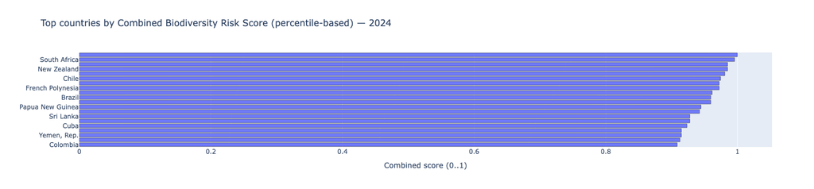

```python
# top by combined score

fig = px.bar(
    top_combined.sort_values("combined_score", ascending=True),
    x="combined_score", y="geo_name",
    orientation="h",
    title="Top countries by Combined Biodiversity Risk Score (percentile-based) — 2024",
    hover_data=["geo_iso3","endemic_pct","threat_pct"]
)

fig.update_layout(yaxis_title="", xaxis_title="Combined score (0..1)")
fig.update_traces(marker=dict(line=dict(width=0.5, color="black")), opacity=0.9)
fig.write_html("top_countries_biodiv_risk.html")
fig.show()
```

### Combined score (data-driven shortlist)

To create a simple shortlist of “high overall biodiversity risk profiles”, we combined:

- **Endemic share (%)**
- **Threat share (%)**

We used **percentile ranks** (0..1) for each metric and averaged them:

- a country gets a high score if it is high relative to others on both dimensions.

This is not a “true risk model” yet — it is an interpretable **screening score** to identify candidates for deeper analysis (e.g., linking to land use, agriculture, freshwater withdrawals, or financial exposure).

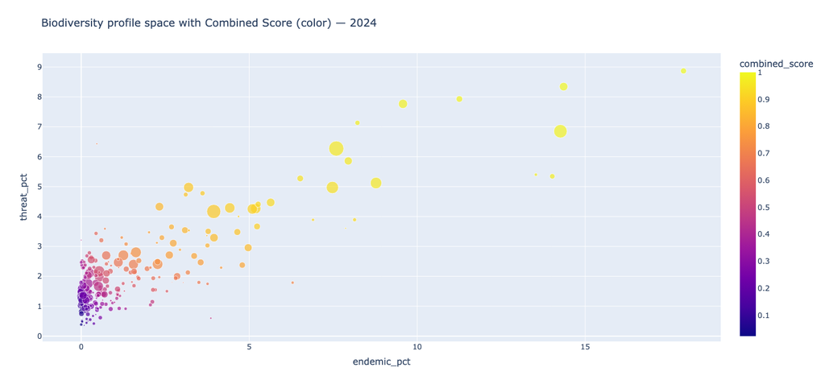

```python
fig = px.scatter(
    df_score,
    x="endemic_pct", y="threat_pct",
    color="combined_score",
    size="total_species" if "total_species" in df_score.columns else None,
    hover_name="geo_name",
    hover_data=["geo_iso3","combined_score"],
    title="Biodiversity profile space with Combined Score (color) — 2024"
)
fig.update_layout(
    width=1600,          # по вкусу: 900–1200
    height=700,         # по вкусу: 600–800
    font=dict(size=14)  # общий шрифт
)
fig.write_html("biodiv_profile_space_risk.html")
fig.show()
```

## Limitations Scope & Data Constraints

- **Single-year snapshot (2024 only).**  
  This dataset contains one time point, so we **cannot analyze trends, growth/decline, or momentum** in biodiversity risk. All insights reflect a *cross-sectional* comparison in 2024.
- **Country-level aggregation.**  
  Indicators are reported at the national level. This can **hide strong within-country variation** (regional hotspots, protected areas, coastal vs inland, etc.). It is not suitable for site-level decisions without additional spatial data.
- **Limited indicator set (only 3 metrics).**  
  We only observe:
  - total species,
  - threatened species (probability threshold definition),
  - endemic small-range species.  
    This does **not** capture key drivers such as land-use change, habitat fragmentation, pollution, invasive species, climate stress, or conservation policy intensity.
- **Comparability issues: “absolute” vs “relative” measures.**  
  Absolute counts (e.g., total species, threatened species) are strongly influenced by **country size and ecological richness**.  
  Shares (threat %, endemic %) are more comparable, but still depend on **how species totals are estimated**.
- **Definition and measurement uncertainty.**  
  Species counts and threat estimates rely on ecological models/assessments and can include:
  - uneven monitoring capacity across countries,
  - reporting/estimation differences,
  - uncertainty in how “small-range endemics” are defined.  
    Therefore, results should be treated as **indicative**, not as exact ground truth.
- **Coverage and missingness are still possible.**  
  Even if our wide table has no missing values for 2024, this does not guarantee perfect coverage: some territories may be included/excluded differently than standard country lists, and names/ISO mappings can affect joins with other datasets.
- **Not a causal analysis.**  
  Correlations or country rankings here **do not imply causality**. We cannot claim that one factor “causes” higher threat share or endemic share without adding explanatory variables and a causal design.
- **Not yet a financial risk model.**  
  The combined score is a **screening tool** based on biodiversity indicators only. To connect this to credit/insurance/business risk, we would need additional data (e.g., sector exposure, land-use intensity, supply-chain location, ecosystem dependency, loss events, regulatory risk).